# Project: Medical Appointment Report - No show appointment

- Introduction
- Data Wrangling
- Exploratory Data Analysis
- Conclusions

## Introduction

### No-show Dataset Description

> This report describes the medical appointment of patients who showed up for their appointment and those that were absent. Different characteristics of the patients who went for appointment were also reported. Those characteristics includes the patients's identification number (ID), the patient's appointment ID number, the gender of the patients whether they are male or female, the scheduled day given to the patient, the appointment day to see the medical personel and the neighbourhood of the patient. Moreso, the age of the patients, the number of patients who enrolled in the Brasilian welfare program Bolsa Família", hencing receiving scholarship and those who did not, the number of patients with various health challenges such as hypertension, diabetes, being handicapped and the number of alcoholic patients were all represented in the report. Finally, the number of patients who received SMS,those that showed up for the appointment and those that did not show up for appointment were all represented in the report.

### Question(s) for Analysis

> Furthermore, the various characteristics enumerated above were explored to know the relationship that exist between them. This further provide insights into the patient's personality and to highlight the factors that would make the patients show up for medical appointment. To achieve these, several questions were asked and some of the questions include:
> 1. What factors determine whether a patient will show up for appointment or not?
> 2. Does receiving SMS and being enrolled in the scholarship program influence more patients to show up for appointment?
> 3. Does being handicapped and having little health challenges hinder patients from showing up on the appointment day?
> 4. What is the age bracket of patients who showed up the most for appointment? These questions and **many more** will be addressed in the **data analysis** and **conclusion** sections.

```python
#Load the dataset
import pandas as pd
import numpy as np
import matplotlib.pyplot as plt
import seaborn as sns
%matplotlib inline
```

```python
# Upgrade pandas to use dataframe.explode() function.
!pip install --upgrade pandas==0.25.0
```

## Data Wrangling

### General Properties

> In this section, the dataset in "csv" file will be read, checked, trimmed, cleaned and organized.

```python
# Read the loaded CSV file
df = pd.read_csv('noshow.csv', sep= ',')

# View the column head of the dataset
df.head()
```

|  | PatientId | AppointmentID | Gender | ScheduledDay | AppointmentDay | Age | Neighbourhood | Scholarship | Hipertension | Diabetes | Alcoholism | Handcap | SMS_received | No-show |
| --- | --- | --- | --- | --- | --- | --- | --- | --- | --- | --- | --- | --- | --- | --- |
| 0 | 2.987250e+13 | 5642903 | F | 2016-04-29T18:38:08Z | 2016-04-29T00:00:00Z | 62 | JARDIM DA PENHA | 0 | 1 | 0 | 0 | 0 | 0 | No |
| 1 | 5.589978e+14 | 5642503 | M | 2016-04-29T16:08:27Z | 2016-04-29T00:00:00Z | 56 | JARDIM DA PENHA | 0 | 0 | 0 | 0 | 0 | 0 | No |
| 2 | 4.262962e+12 | 5642549 | F | 2016-04-29T16:19:04Z | 2016-04-29T00:00:00Z | 62 | MATA DA PRAIA | 0 | 0 | 0 | 0 | 0 | 0 | No |
| 3 | 8.679512e+11 | 5642828 | F | 2016-04-29T17:29:31Z | 2016-04-29T00:00:00Z | 8 | PONTAL DE CAMBURI | 0 | 0 | 0 | 0 | 0 | 0 | No |
| 4 | 8.841186e+12 | 5642494 | F | 2016-04-29T16:07:23Z | 2016-04-29T00:00:00Z | 56 | JARDIM DA PENHA | 0 | 1 | 1 | 0 | 0 | 0 | No |

```python
# Check for the total number of patients and total number of features
df.shape
```

```
(110527, 14)
```

#### Comment 1

> This analysis showed that the total number of patients in the dataset are 110,527 patients with 14 various features.

```python
# Get more information to understand the dataset
df.info()
```

```
<class 'pandas.core.frame.DataFrame'>
RangeIndex: 110527 entries, 0 to 110526
Data columns (total 14 columns):
 #   Column          Non-Null Count   Dtype
---  ------          --------------   -----
 0   PatientId       110527 non-null  float64
 1   AppointmentID   110527 non-null  int64
 2   Gender          110527 non-null  object
 3   ScheduledDay    110527 non-null  object
 4   AppointmentDay  110527 non-null  object
 5   Age             110527 non-null  int64
 6   Neighbourhood   110527 non-null  object
 7   Scholarship     110527 non-null  int64
 8   Hipertension    110527 non-null  int64
 9   Diabetes        110527 non-null  int64
 10  Alcoholism      110527 non-null  int64
 11  Handcap         110527 non-null  int64
 12  SMS_received    110527 non-null  int64
 13  No-show         110527 non-null  object
dtypes: float64(1), int64(8), object(5)
memory usage: 11.8+ MB
```

#### Comment 2

> This analysis gives the summary of the dataset. They are listed below
> 1. There are total 14 features that gives the information about the patients
> 2. There appear to be no missing value as the total number of each feature equals to the total number of the patients
> 3. The data type of the dataset showed that we have **8** columns which have integer values, **1** column which is a float and **5** columns as object.
> 4. The object data type can be misleading, we will need to explore these columns to know if they are strings or combination of both strings and integers.

```python
#Check the data type of 'No-show' column
type(df['Gender'][0])
```

```
str
```

```python
type(df['ScheduledDay'][0])
```

```
str
```

```python
type(df['AppointmentDay'][0])
```

```
str
```

```python
type(df['Neighbourhood'][0])
```

```
str
```

```python
type(df['No-show'][0])
```

```
str
```

```python
type(df['PatientId'][0])
```

```
numpy.float64
```

#### Comment 3

> We can see that the 5 columns containing objects are all strings. So let us confirm this by checking the arrays of each 5 columns

```python
df['Gender'].unique()
```

```
array(['F', 'M'], dtype=object)
```

```python
df['ScheduledDay'].unique()
```

```
array(['2016-04-29T18:38:08Z', '2016-04-29T16:08:27Z',
       '2016-04-29T16:19:04Z', ..., '2016-04-27T16:03:52Z',
       '2016-04-27T15:09:23Z', '2016-04-27T13:30:56Z'], dtype=object)
```

```python
df['AppointmentDay'].unique()
```

```
array(['2016-04-29T00:00:00Z', '2016-05-03T00:00:00Z',
       '2016-05-10T00:00:00Z', '2016-05-17T00:00:00Z',
       '2016-05-24T00:00:00Z', '2016-05-31T00:00:00Z',
       '2016-05-02T00:00:00Z', '2016-05-30T00:00:00Z',
       '2016-05-16T00:00:00Z', '2016-05-04T00:00:00Z',
       '2016-05-19T00:00:00Z', '2016-05-12T00:00:00Z',
       '2016-05-06T00:00:00Z', '2016-05-20T00:00:00Z',
       '2016-05-05T00:00:00Z', '2016-05-13T00:00:00Z',
       '2016-05-09T00:00:00Z', '2016-05-25T00:00:00Z',
       '2016-05-11T00:00:00Z', '2016-05-18T00:00:00Z',
       '2016-05-14T00:00:00Z', '2016-06-02T00:00:00Z',
       '2016-06-03T00:00:00Z', '2016-06-06T00:00:00Z',
       '2016-06-07T00:00:00Z', '2016-06-01T00:00:00Z',
       '2016-06-08T00:00:00Z'], dtype=object)
```

```python
df['Neighbourhood'].unique()
```

```
array(['JARDIM DA PENHA', 'MATA DA PRAIA', 'PONTAL DE CAMBURI',
       'REPÚBLICA', 'GOIABEIRAS', 'ANDORINHAS', 'CONQUISTA',
       'NOVA PALESTINA', 'DA PENHA', 'TABUAZEIRO', 'BENTO FERREIRA',
       'SÃO PEDRO', 'SANTA MARTHA', 'SÃO CRISTÓVÃO', 'MARUÍPE',
       'GRANDE VITÓRIA', 'SÃO BENEDITO', 'ILHA DAS CAIEIRAS',
       'SANTO ANDRÉ', 'SOLON BORGES', 'BONFIM', 'JARDIM CAMBURI',
       'MARIA ORTIZ', 'JABOUR', 'ANTÔNIO HONÓRIO', 'RESISTÊNCIA',
       'ILHA DE SANTA MARIA', 'JUCUTUQUARA', 'MONTE BELO',
       'MÁRIO CYPRESTE', 'SANTO ANTÔNIO', 'BELA VISTA', 'PRAIA DO SUÁ',
       'SANTA HELENA', 'ITARARÉ', 'INHANGUETÁ', 'UNIVERSITÁRIO',
       'SÃO JOSÉ', 'REDENÇÃO', 'SANTA CLARA', 'CENTRO', 'PARQUE MOSCOSO',
       'DO MOSCOSO', 'SANTOS DUMONT', 'CARATOÍRA', 'ARIOVALDO FAVALESSA',
       'ILHA DO FRADE', 'GURIGICA', 'JOANA D´ARC', 'CONSOLAÇÃO',
       'PRAIA DO CANTO', 'BOA VISTA', 'MORADA DE CAMBURI', 'SANTA LUÍZA',
       'SANTA LÚCIA', 'BARRO VERMELHO', 'ESTRELINHA', 'FORTE SÃO JOÃO',
       'FONTE GRANDE', 'ENSEADA DO SUÁ', 'SANTOS REIS', 'PIEDADE',
       'JESUS DE NAZARETH', 'SANTA TEREZA', 'CRUZAMENTO',
       'ILHA DO PRÍNCIPE', 'ROMÃO', 'COMDUSA', 'SANTA CECÍLIA',
       'VILA RUBIM', 'DE LOURDES', 'DO QUADRO', 'DO CABRAL', 'HORTO',
       'SEGURANÇA DO LAR', 'ILHA DO BOI', 'FRADINHOS', 'NAZARETH',
       'AEROPORTO', 'ILHAS OCEÂNICAS DE TRINDADE', 'PARQUE INDUSTRIAL'],
      dtype=object)
```

```python
df['No-show'].unique()
```

```
array(['No', 'Yes'], dtype=object)
```

```python
df['PatientId'].unique()
```

```
array([2.98724998e+13, 5.58997777e+14, 4.26296230e+12, ...,
       7.26331493e+13, 9.96997666e+14, 1.55766317e+13])
```

```python
df['Handcap'].nunique()

# This tells that the patients are distributed among the 5 stages of handicap
```

```
5
```

```python
#Understand the statistics of the dataset
df.describe()
```

|  | PatientId | AppointmentID | Age | Scholarship | Hipertension | Diabetes | Alcoholism | Handcap | SMS_received |
| --- | --- | --- | --- | --- | --- | --- | --- | --- | --- |
| count | 1.105270e+05 | 1.105270e+05 | 110527.000000 | 110527.000000 | 110527.000000 | 110527.000000 | 110527.000000 | 110527.000000 | 110527.000000 |
| mean | 1.474963e+14 | 5.675305e+06 | 37.088874 | 0.098266 | 0.197246 | 0.071865 | 0.030400 | 0.022248 | 0.321026 |
| std | 2.560949e+14 | 7.129575e+04 | 23.110205 | 0.297675 | 0.397921 | 0.258265 | 0.171686 | 0.161543 | 0.466873 |
| min | 3.921784e+04 | 5.030230e+06 | -1.000000 | 0.000000 | 0.000000 | 0.000000 | 0.000000 | 0.000000 | 0.000000 |
| 25% | 4.172614e+12 | 5.640286e+06 | 18.000000 | 0.000000 | 0.000000 | 0.000000 | 0.000000 | 0.000000 | 0.000000 |
| 50% | 3.173184e+13 | 5.680573e+06 | 37.000000 | 0.000000 | 0.000000 | 0.000000 | 0.000000 | 0.000000 | 0.000000 |
| 75% | 9.439172e+13 | 5.725524e+06 | 55.000000 | 0.000000 | 0.000000 | 0.000000 | 0.000000 | 0.000000 | 1.000000 |
| max | 9.999816e+14 | 5.790484e+06 | 115.000000 | 1.000000 | 1.000000 | 1.000000 | 1.000000 | 4.000000 | 1.000000 |

#### Comment 4

> This analysis gives the descriptive statistics of the dataset. They are listed below
> 1. The Age distribution of the patients showed that more than 50% of the patients are from 0-37 years and 75% of the patients are in the range of 0-55years.
> 2. Most of the patients did not enroll for the scholarship program (Brasilian welfare program, Bolsa Família).
> 3. Most of the patients are not diabetic, not hypertensive, do not drink alcohol and are not handicapped.
> 4. Moreso, most of the patients did not receive SMS.
> 5. There seems to be an outlier in the age column because there is a row having the age to be -1.

```python
#Check for sum of duplication in the data
sum(df.duplicated())
```

```
0
```

```python
#check for sum of missing data for rows
sum(df.isnull().values.any(axis=1))
```

```
0
```

```python
# Check for missing data for columns
df.isnull().sum().any()
```

```
False
```

#### Comment 5

> As predicted, there were no missing values both in the rows and columns and there are no duplicated values too.

### Data Cleaning

> In this section, we will be cleaning the dataset by renaming columns for easy exploration, dropping unnecessary columns and trimming the data as well.

```python
# Rename those without space and add underscore for easy workthrough
df.rename(columns={'scheduledday': 'scheduled_day','appointmentday': 'appointment_day', 'handcap':'handicapped', 'hipertension':'hypertension'}, inplace=True)

# Confirm changes
df.head(1)
```

|  | PatientId | AppointmentID | Gender | ScheduledDay | AppointmentDay | Age | Neighbourhood | Scholarship | Hipertension | Diabetes | Alcoholism | Handcap | SMS_received | No-show |
| --- | --- | --- | --- | --- | --- | --- | --- | --- | --- | --- | --- | --- | --- | --- |
| 0 | 2.987250e+13 | 5642903 | F | 2016-04-29T18:38:08Z | 2016-04-29T00:00:00Z | 62 | JARDIM DA PENHA | 0 | 1 | 0 | 0 | 0 | 0 | No |

```python
# Drop columns if necessary
df.drop(['PatientId', 'AppointmentID', 'Neighbourhood'], axis=1, inplace=True)
```

```python
# Rename column if necessary for easy workthrough and work on the No-show column too
df.rename(columns=lambda x: x.strip().lower().replace("-", "_"), inplace=True)

# Check if the changes for rename has been made
df.head(1)
```

|  | gender | scheduledday | appointmentday | age | scholarship | hipertension | diabetes | alcoholism | handcap | sms_received | no_show |
| --- | --- | --- | --- | --- | --- | --- | --- | --- | --- | --- | --- |
| 0 | F | 2016-04-29T18:38:08Z | 2016-04-29T00:00:00Z | 62 | 0 | 1 | 0 | 0 | 0 | 0 | No |

```python
# Rename those without soace and add underscore for easy workthrough
df.rename(columns={'scheduledday': 'scheduled_day','appointmentday': 'appointment_day', 'handcap':'handicapped', 'hipertension':'hypertension'}, inplace=True)

# Confirm changes
df.head(1)
```

|  | gender | scheduled_day | appointment_day | age | scholarship | hypertension | diabetes | alcoholism | handicapped | sms_received | no_show |
| --- | --- | --- | --- | --- | --- | --- | --- | --- | --- | --- | --- |
| 0 | F | 2016-04-29T18:38:08Z | 2016-04-29T00:00:00Z | 62 | 0 | 1 | 0 | 0 | 0 | 0 | No |

### Check the data type of all columns and be sure they are uniform. If they are not, work on them to attain consistency

> From the information obtained above, it is glaring that scheduled_day and appointment_day are not in the right data type format

```python
# Convert scheduled_day and appointment_day to datetime type
df['scheduled_day'] = pd.to_datetime(df['scheduled_day'])
df['appointment_day'] = pd.to_datetime(df['appointment_day'])
```

```python
#Drop the time from datetime column (scheduled_day and appointment_day)
df['scheduled_day'] = df['scheduled_day'].dt.date
df['appointment_day'] = df['appointment_day'].dt.date

# Confirm changes made
df.head()
```

|  | gender | scheduled_day | appointment_day | age | scholarship | hypertension | diabetes | alcoholism | handicapped | sms_received | no_show |
| --- | --- | --- | --- | --- | --- | --- | --- | --- | --- | --- | --- |
| 0 | F | 2016-04-29 | 2016-04-29 | 62 | 0 | 1 | 0 | 0 | 0 | 0 | No |
| 1 | M | 2016-04-29 | 2016-04-29 | 56 | 0 | 0 | 0 | 0 | 0 | 0 | No |
| 2 | F | 2016-04-29 | 2016-04-29 | 62 | 0 | 0 | 0 | 0 | 0 | 0 | No |
| 3 | F | 2016-04-29 | 2016-04-29 | 8 | 0 | 0 | 0 | 0 | 0 | 0 | No |
| 4 | F | 2016-04-29 | 2016-04-29 | 56 | 0 | 1 | 1 | 0 | 0 | 0 | No |

##### As stated above, there is an outlier in the age column where the age is -1. Sort out this outlier

```python
# Check the array of the age column to find out which row has -1.
df['age'].unique()

# It can be seen that no patient can be -1, so drop that row.
```

```
array([ 62,  56,   8,  76,  23,  39,  21,  19,  30,  29,  22,  28,  54,
        15,  50,  40,  46,   4,  13,  65,  45,  51,  32,  12,  61,  38,
        79,  18,  63,  64,  85,  59,  55,  71,  49,  78,  31,  58,  27,
         6,   2,  11,   7,   0,   3,   1,  69,  68,  60,  67,  36,  10,
        35,  20,  26,  34,  33,  16,  42,   5,  47,  17,  41,  44,  37,
        24,  66,  77,  81,  70,  53,  75,  73,  52,  74,  43,  89,  57,
        14,   9,  48,  83,  72,  25,  80,  87,  88,  84,  82,  90,  94,
        86,  91,  98,  92,  96,  93,  95,  97, 102, 115, 100,  99,  -1],
      dtype=int64)
```

```python
# View the row with age being -1
df_age = df.loc[df['age'] == -1]
print(df_age)
```

```
      gender scheduled_day appointment_day  age  scholarship  hypertension  \
99832      F    2016-06-06      2016-06-06   -1            0             0

       diabetes  alcoholism  handicapped  sms_received no_show
99832         0           0            0             0      No
```

```python
# Drop the row with age being -1
df.drop(df.query('age==-1').index, inplace=True)
df_age = df.loc[df['age'] == -1]

# Confirm changes
print(df_age)
```

```
Empty DataFrame
Columns: [gender, scheduled_day, appointment_day, age, scholarship, hypertension, diabetes, alcoholism, handicapped, sms_received, no_show]
Index: []
```

#### Since we are particularly interested in the "no_show" column. Try to work on this column for easy exploration

> *Action 1:* _Work on the **"no_show"** column and convert the string to integers for easy representation_.  
> *Action 2:* _Note that **"no_show"** is tagged ‘No’ if the patient **SHOWED UP** to their appointment, and ‘Yes’ if they **did NOT show up**_

```python
# First check the number of patients that showed up and those that did not show up for appointment.

df['no_show'].value_counts()
```

```
No     88207
Yes    22319
Name: no_show, dtype: int64
```

#### Comment 6

**Result:** 88,207 patients showed up for appointment and 22,319 patients did not show up.

```python
# For easy exploration, replace the 'Yes' with 0 and the 'No' with 1 so as not to be confused when exploring the data

df['no_show'] = df['no_show'].replace({'Yes': 0, 'No': 1})

# Confirm that the number of patients who showed are the same with the previous cell.
df['no_show'].value_counts()

# Source:  https://www.statology.org/pandas-convert-boolean-to-int/
```

```
1    88207
0    22319
Name: no_show, dtype: int64
```

## Exploratory Data Analysis 1

> Now that the data is trimmed and cleaned. View the graphical representation of all the columns to understand the data.

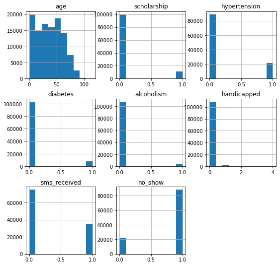

```python
# Drop the scheduled_day and appointment_day columns because the graph can be messy and view other columns on histogram.
df_plot = df.drop(columns=['scheduled_day', 'appointment_day']).hist(figsize=(9, 9));
df_plot;
```

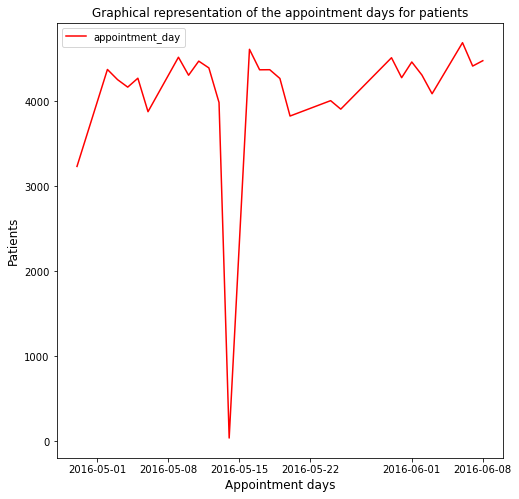

```python
# View the line graph for the two columns dropped (scheduled_day and appointment_day).

df['appointment_day'].value_counts().plot(kind='line', color='r', figsize=(8,8));
plt.xlabel('Appointment days', fontsize= 12);
plt.ylabel('Patients', fontsize= 12);
plt.title('Graphical representation of the appointment days for patients', fontsize= 12);
plt.legend();
```

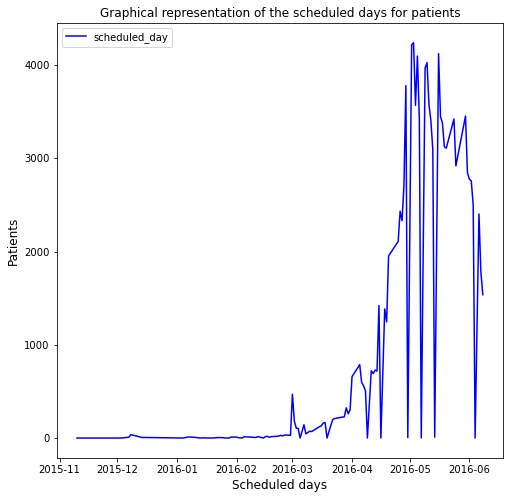

```python
df['scheduled_day'].value_counts().plot(kind='line', color='b', figsize=(8,8));
plt.xlabel('Scheduled days', fontsize= 12);
plt.ylabel('Patients', fontsize= 12);
plt.title('Graphical representation of the scheduled days for patients', fontsize= 12);
plt.legend();
```

#### Comment 7

> 1. From the graphical overview of the dataset, the age histogram seems skewed more to the left, suggesting that more patients are within the age of 0-40years old.
> 2. Patients that DID NOT enroll for scholarship are more than those that enrolled for the scholarship program.
> 3. Patients with NO diabetes, NO hypertension, NON-alcoholic, NOT handicapped are more than those with these conditions.
> 4. Patients who DID NOT received SMS are more than those that received SMS.
> 5. Patients that SHOWED UP for appointment are MORE than those that did not show up for appointment.
> 6. The line plot for the appointment day showed that patients have low turn out for appointment between 13th to 17th May 2016 and the highest turn out of patients for appointment was around 4th to 6th of June 2016.
> 7. The line plot of scheduled days showed that the graph skewed to the right, implying that most patients were scheduled more in the month of May and June of 2016.

## Exploratory Data Analysis 2

> In this section, we will be computing statistics and creating more visualizations. Also, we will be asking some research questions and providing solutions to the questions by computing the relevant statistics and visualizing them on various plots.

### Research Question 1: When is the starting day to schdule an appointment and when is the deadline?

```python
# To do this, check the minimum and maximum of the scheduled day
df["scheduled_day"].min(), df["scheduled_day"].max()
```

```
(datetime.date(2015, 11, 10), datetime.date(2016, 6, 8))
```

**Result:** The scheduled date started on the 10th of Novemeber 2015 and ended on the 8th of June 2016.

### Research Question 2: When did the appointment day start and when did it end?

```python
df["appointment_day"].min(), df["appointment_day"].max()
```

```
(datetime.date(2016, 4, 29), datetime.date(2016, 6, 8))
```

**Result:** The appointment day started on the 29th of April 2016 and ended on the 8th of June 2016.

### Research Question 3: How long does the scheduled day and appointment day span for?

```python
print(df["scheduled_day"].max() - df["scheduled_day"].min())
df["appointment_day"].max() - df["appointment_day"].min()
```

```
211 days, 0:00:00
```

```
datetime.timedelta(days=40)
```

**Result:** The scheduled day spanned for 211 days (about 7months) while the appointment day span for 40 days respectively

### Research Question 4: What is the percentage of patients that showed up for the medical appointments and the percentage that did not show up?

```python
# First create mask for patients that showed up and those that did not show up

showed_up = df[df['no_show'] == 1]
absent = df[df['no_show'] == 0]
```

```python
# Get the count of patient who showed, those who did not show, and the total number of patients
Patient_showed= showed_up['no_show'].count()
Patient_absent = absent['age'].count()
Total_patient = Patient_showed + Patient_absent
Patient_showed, Patient_absent, Total_patient
```

```
(88207, 22319, 110526)
```

```python
Percentage_showed= (Patient_showed/Total_patient)*100
Percentage_showed
```

```
79.80656135208005
```

```python
Percentage_absent= (Patient_absent/Total_patient)*100
Percentage_absent
```

```
20.193438647919944
```

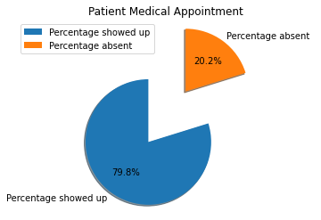

```python
# Representing this visually
data = [79.8, 20.2]
label = ['Percentage showed up', 'Percentage absent']
plt.pie(data, labels=label, autopct='%1.1f%%', explode=[0,1], shadow=True, startangle=90)
plt.title('Patient Medical Appointment')
plt.axis('equal')
plt.legend()
plt.show()

#https://www.tutorialsandyou.com/matplotlib/how-to-show-percentage-and-value-in-matplotlib-pie-chart-12.html
```

**Result:** 79.8% patients showed up for appointment, 20.2% did not show.

### Research Question 5: What factors are important to know in order to predict if a patient will show up on their appointment day or not?

> **1.** First, let's look at two factors at a time to predict if the patient will show up or not.  
> **2.** To achieve this, one of the factors will be an independent variable ('no_show' = 1 column) and the other will be a dependent variable.  
> **3.** Secondly, let's create a function that calls for other factors for patients that showed up and those absent.  
> **4.** Also remember that the ('no_show' = 1) column has been turned to a dataframe.

```python
def beam(var):

    showed_up[var].value_counts().plot(kind="bar",color='red', fontsize=12, label = 'show up', figsize=(6,6))
    absent[var].value_counts().plot(kind="bar",color='blue', fontsize=12, label = 'absent', figsize=(6,6))
    plt.xlabel(var, fontsize = 12)
    plt.ylabel('Number of Patients',fontsize = 12)
    plt.title(f'{var} distribution of patients that showed up for medical appointment VS those absent')
    plt.legend(bbox_to_anchor=(1, 1), loc='upper right', borderaxespad=0.4);
```

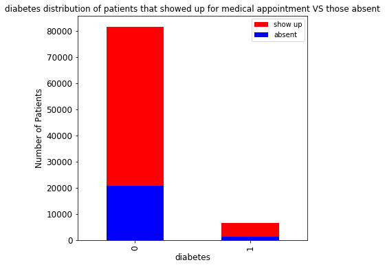

```python
beam('diabetes')
```

```python
# Diabetes as a factor to predict patients who will show up on the scheduled day and those who would not

showed_up['diabetes'].value_counts(), absent['diabetes'].value_counts()
```

```
(0    81694
 1     6513
 Name: diabetes, dtype: int64,
 0    20889
 1     1430
 Name: diabetes, dtype: int64)
```

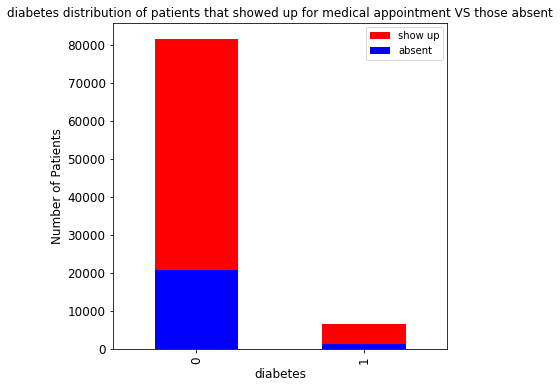

```python
beam('diabetes')
```

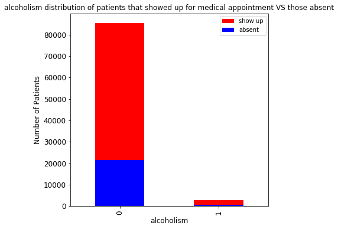

```python
# Let's look at alcoholism as a factor to predict patients who will show up on the appointment day and those who would not

beam('alcoholism')
```

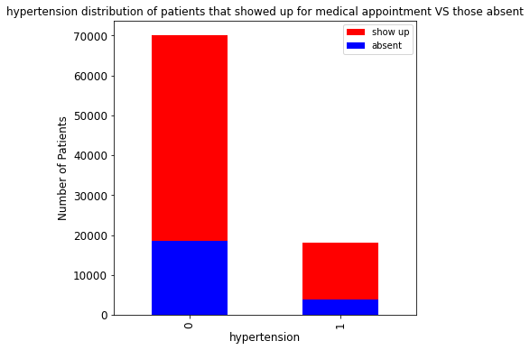

```python
# Let's look at hypertension as a factor to predict patients who will show up on the appointment day and those who would not

beam('hypertension')
```

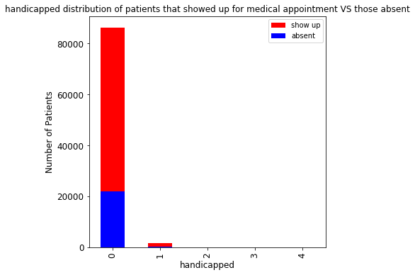

```python
# Let's look at being handicapped as a factor to predict patients who will show up on the appointment day and those who would not

beam('handicapped')
```

**Result:**

> The relationship between patients that showed up and various factors such as diabetes, alcoholism, hypertension, being handicapped (which will now be referred in this cell as ailments) showed that
> 1. The **non-ailment patients** that **showed up** are **MORE** than the **ailment patients** that **showed up**.
> 2. Also, those patients **absent** on the appointment day are **MORE** of **non-ailment patients** than **ailment patients**.
> 3. The number of **non-ailment patients** that **showed up** are **MORE** than the **non-ailment patients** that were **absent**.
> 4. Also, those patients that **showed up** **with ailments** are **MORE** than those patients **absent** **with ailments**.

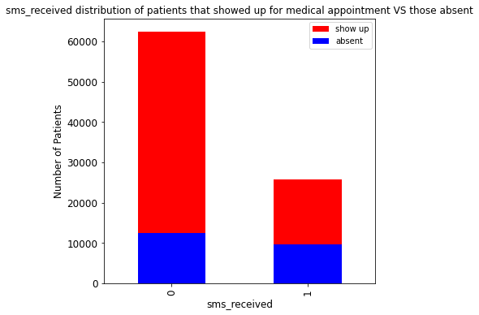

```python
# Let's look at receiving sms as a factor to predict patients who will show up on the appointment day and those who would not.
# This will also answer the question if receiving sms prompts patient to show up on the appointment day or not

beam('sms_received')
```

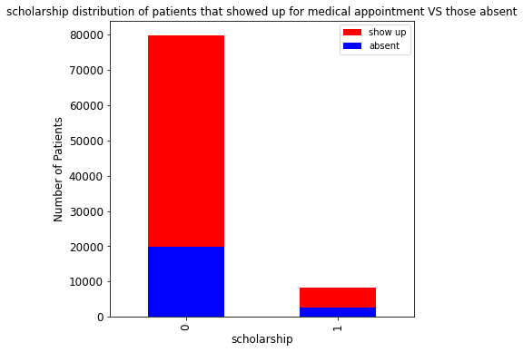

```python
# Let's look at being a scholarship beneficiary as a factor to predict patients who will show up on the appointment day and those who would not.
# This will also answer the question if receiving scholarship prompts patient to show up on the appointment day or not

beam('scholarship')
```

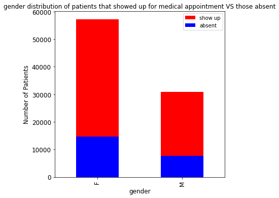

```python
# Let's look at gender as a factor to predict patients who will show up on the appointment day and those who would not.
# This will also answer the question which gender showed up for appointment and which do not

beam('gender')
```

**Result:**

> Irrespective of whether the patients received SMS or were enrolled for the scholarship program (subsequently called benefits), the following observations were made from the graphs
> 1. The patients **with no benefits** that **showed up** are **MORE** than the patients **with benefits** that **showed up**.
> 2. Also, those patients **with no benefits** that **showed up** on the appointment day are **MORE** than those patients **with no benefits** that were **absent**.
> 3. In addition, **MORE** **female** patients **showed up** for the appointmeny than the **male** patients that **showed up** for the appointment.
> 4. Again, **MORE** female patients were **absent** than the male patients **absent** for the appointment.
> 5. **MORE** female patients **showed up** than the female patients **absent**.
> 6. **MORE** male patients **showed up** than the male patients **absent**.

### Research Question 6: What is the age distribution of patients that showed up for appointment and those that did not show?

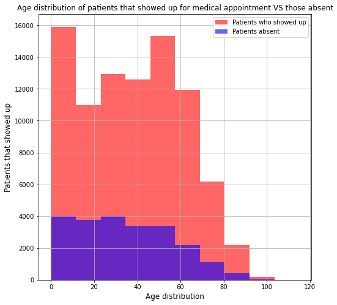

```python
# The "beam" function created above presents the result in a bar chart which will be messy to use for age as a variable.
# So, let's view the age distribution of people that showed up in a histogram. That will give a clear representation.

showed_up['age'].hist(figsize=(8, 8), alpha=0.6, label="Patients who showed up", color ='red')
absent['age'].hist(figsize=(8, 8), alpha=0.6, label="Patients absent", color = 'blue')
plt.xlabel('Age distribution', fontsize=12);
plt.ylabel('Patients that showed up', fontsize=12);
plt.title("Age distribution of patients that showed up for medical appointment VS those absent");
plt.legend();
```

**Result:**

> 1. From the graph, it can be seen that graph seems skewed to the left, suggesting that the patients that SHOWED UP the most were within the age range of 0-15 years old, followed by patients within the age range of 45-58years old.
> 2. The patients that DID NOT SHOW UP the most were also predicted to be in the age range of 0-37 years old.

### Research Question 7: Do ALL patients given scheduled day show up on the scheduled day?

```python
# Also, the "beam" function created above would not give a clear description to know if all patients showed up on the scheduled day unless it is represented in a line graph
# So let us create another function called 'fin'

def fin(var):

    showed_up[var].value_counts().plot(kind='line', color='red', label= 'show up', figsize=(8,8),);
    absent[var].value_counts().plot(kind='line', color='blue', label= 'absent', figsize=(8,8));
    plt.xlabel(var, fontsize = 12)
    plt.ylabel('Number of Patients',fontsize = 12)
    plt.title(f'{var} for showed up patients')
    plt.legend(bbox_to_anchor=(1, 1), loc='upper right', borderaxespad=0.4);
```

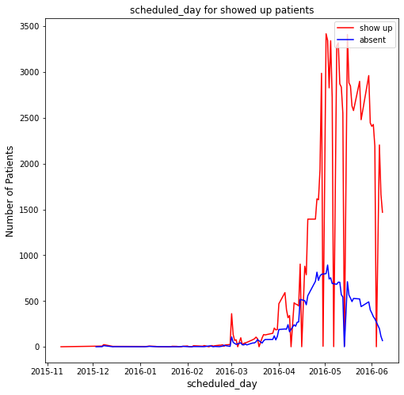

```python
fin('scheduled_day')
```

**Result:**

> 1. From the line graph, not all patients given a scheduled day showed up on the scheduled day.
> 2. As seen in the blue line graph, there were some patients absent on the scheduled day.
> 3. However, the patients who showed up on the scheduled day were more than those who were absent on the scheduled day.
> 4. It is observed that the graph skewed to the right, implying that most patients that showed up on the scheduled day showed up towards the set deadline given for the scheduled period. Specifically, most patients turned up in the month of May 2016.

### Research Question 8: Do ALL patients given appointments show up on the appointment day?

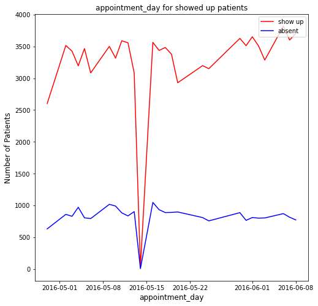

```python
fin('appointment_day')
```

**Result:**

> 1. From the line graph, not all patients given appointment showed up on the appointment day.
> 2. As seen in the blue line graph, there were some patients absent on the appointment day.
> 3. However, the patients who showed up on the appointment day were more than those who were absent on the appointment day.
> 4. In addition, low turn out of patients on the appointment day was seen in the month of May, 2016.
> 5. The high turn out of patients for appointments is observed between the 1st and 8th of June, 2016.

### Research Question 9: Does your analysis show that ALL those who showed up on the scheduled day also showed up on the appointment day?

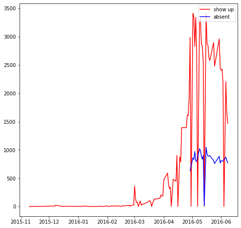

```python
# Let's visualize whether ALL patients given scheduled day showed up on the appointment day
showed_up['scheduled_day'].value_counts().plot(kind='line', color='r', label= 'show up', figsize=(8,8));
absent['appointment_day'].value_counts().plot(kind='line', color='b', label= 'absent', figsize=(8,8));
plt.legend(bbox_to_anchor=(1, 1), loc='upper right', borderaxespad=0.4);
```

**Result:**

> 1. The **red line graph** shows the patients that **SHOWED UP** on the **scheduled day** and the **blue line graph** showed the patients that were **ABSENT** on the **appointment day**. From the line graph, it is seen that;
> 2. Not all patients who showed up on the scheduled day showed up on the appointment day because the blue line graph still shows on the graph above.

### Research Question 10: What gender of patients received more scholarship?

```python
Gender_scholarship = df.groupby('scholarship')['gender'].value_counts()
Gender_scholarship
```

```
scholarship  gender
0            F         62986
             M         36679
1            F          8853
             M          2008
Name: gender, dtype: int64
```

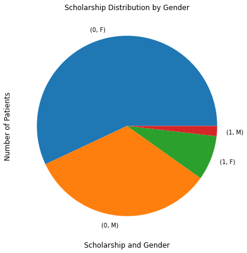

```python
# Let's plot the graph of scholarship distribution based on gender
Gender_scholarship.plot(kind="pie", figsize=(7,7), subplots=True);
plt.xlabel("Scholarship and Gender", fontsize = 12)
plt.ylabel('Number of Patients',fontsize = 12)
plt.title('Scholarship Distribution by Gender');
```

**Result:**

> The relationship between gender and scholarship showed that:
> 1. More female patients are enrolled for scholarship than the male patients.
> 2. Comparing the male that were enolled for scholarship and those that were not,it was found that more male did not enroll for scholarship than the male that were enrolled.
> 3. The same goes for female too. So most patients in total do not enroll for scholarship.

### Research Question 11: What gender of patients takes alcohol the most?

```python
df.groupby('alcoholism')['gender'].value_counts()
```

```
alcoholism  gender
0           F         70616
            M         36550
1           M          2137
            F          1223
Name: gender, dtype: int64
```

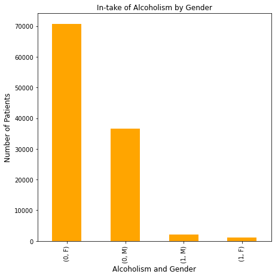

```python
# Let's visualize the gender of patients takes alcohol the most?

df.groupby('alcoholism')['gender'].value_counts().plot(kind="bar",figsize=(7,7), color=('orange'));
plt.xlabel("Alcoholism and Gender", fontsize = 12)
plt.ylabel('Number of Patients',fontsize = 12)
plt.title('In-take of Alcoholism by Gender');
```

**Result:**

> The relationship between alcoholism and gender showed that
> 1. **MORE male** patients **takes** alcohol than the **females** patients who **takes** alcohol.
> 2. **MORE females** patients **do not** take alcohol than the **male** who also **do not** takes alcohol
> 3. **MORE** patients **do not** take alcohol than the patients that **takes** alcohol.

### Research Question 12: Graphically, show what age distribution of patients receive more scholarship?

```python
# # So let us create another function called 'pin'

def pin(var1, var2):
    df.query(var1)[var2].plot(kind="hist", figsize=(7,7), color=('blue'))
    plt.xlabel(var2, fontsize = 12)
    plt.ylabel(var1,fontsize = 12)
    plt.title(f'{var2} and {var1} for patients');
```

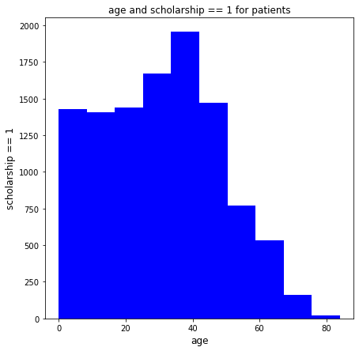

```python
pin('scholarship == 1','age')
```

**Result:**

> The age bracket of patients who enrolled for the scholarship program were between mostly in the range of 27-43 years old

### Research Question 13: Are patients who are handicapped prone to taking alcohol??

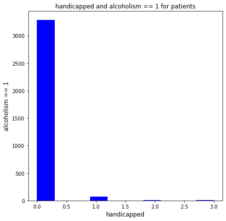

```python
# Could it be that patients who takes alcohol is due to their being handicapped? Let's visualize it

pin('alcoholism == 1', 'handicapped')
```

**Result:**

> From the graph, patients who are handicapped **are not** prone to taking alcohol

### Research Question 14: How many patients received SMS and how many did not received the SMS?

```python
df.query('sms_received == 1').shape, df.query('sms_received == 0').shape
```

```
((35482, 11), (75044, 11))
```

**Result:**

> 35,482 patients received SMS and 75,044 patients did not receive SMS. More patients **did not receive SMS** than those that received SMS.

### Research Question 15: Do patients who received SMS and scholarship show up for appointment more than those who do not receive the two?

> Now, we are looking at three factors at a time to predict if the patient will show up or not. To achieve this, one of the factors will be an independent variable ('no_show' = 1 column) and the other two will be dependent variables. Secondly, let's create another function called **hit_plot** that calls for other factors for only patients that showed up. Also remember that the ('no_show' = 1) column has been turned to a dataframe.

```python
# Patients who showed up, received SMS and are also enrolled for scholarship

showed_up.groupby(['sms_received', 'scholarship']).count()
```

| sms_received | scholarship | gender | scheduled_day | appointment_day | age | hypertension | diabetes | alcoholism | handicapped | no_show |
| --- | --- | --- | --- | --- | --- | --- | --- | --- | --- | --- |
| 0 | 0 | 56547 | 56547 | 56547 | 56547 | 56547 | 56547 | 56547 | 56547 | 56547 |
|  | 1 | 5962 | 5962 | 5962 | 5962 | 5962 | 5962 | 5962 | 5962 | 5962 |
| 1 | 0 | 23377 | 23377 | 23377 | 23377 | 23377 | 23377 | 23377 | 23377 | 23377 |
|  | 1 | 2321 | 2321 | 2321 | 2321 | 2321 | 2321 | 2321 | 2321 | 2321 |

```python
# Patients who DID not show up, but received SMS and are also enrolled for scholarship

absent.groupby(['sms_received', 'scholarship']).count()['no_show']
```

```
sms_received  scholarship
0             0              11141
              1               1394
1             0               8600
              1               1184
Name: no_show, dtype: int64
```

```python
#Since the values are the same all through, the subsequent codes will be grouped against no_show column
#So, let's create a function to loop through patients who showed with with two other variables.

def hit_plot(var1,var2):
    showed_up.groupby([var1,var2]).count()["no_show"].plot(kind="bar",color='red',alpha=.5, fontsize=12, label = 'show up', figsize=(6,6))
    absent.groupby([var1,var2]).count()["no_show"].plot(kind="bar",color='blue',alpha=.5, fontsize=12, label = 'absent', figsize=(6,6))
    plt.xlabel(f"{var1} and {var2}", fontsize=12)
    plt.ylabel('Number of Patients',fontsize = 12)
    plt.title(f'{var1} and {var2} for showed up patients')
    plt.legend(bbox_to_anchor=(1, 1), loc='upper right', borderaxespad=0.4);
```

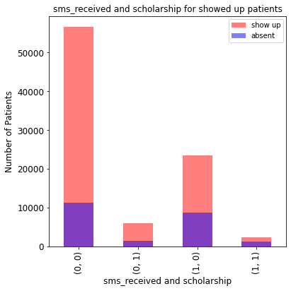

```python
hit_plot('sms_received', 'scholarship')
```

**Result:**

> 1. From the graph above, the patients who showed up for appointment, who DO NOT receive SMS and ARE NOT enrolled for scholarship are more than the patients that showed up for appointment but received these benefits (scholarship and SMS). Therefore, patients who receive SMS and scholarship and showed up for appointment are LESS than those who do not receive the two.

### Research Question 16: Could it be that the patients who did not show up for appointment is due to their health challenges (diabetes and hypertension)?

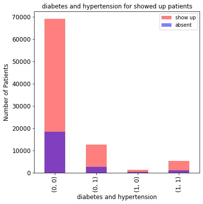

```python
# Let us visualize Diabetic and hypertensiveness as a factor to show up for appointment
hit_plot('diabetes', 'hypertension')
```

**Result:**

> 1. From the graph above, the patients who **DID NOT SHOW UP** was not because they have diabetes or are hypertensive. This is because the graph in the blue bar chart of the patients absent is highest for those without any of these health challenges.

### Research Question 17: Could it be that the patients who did not show up is because they were handicapped and they are given to alcohol?

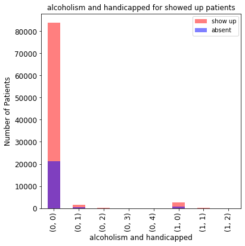

```python
# Let's see the visual representation of alcoholism and being handicapped as a factor to show up for appointment
hit_plot('alcoholism', 'handicapped')
```

**Result:**

> 1. From the graph above, the patients who **DID NOT SHOW UP** for appointment the most was not because they are alcoholic nor are handicapped. The patients that did not show up are more of patients who are **not handicapped and are non-alcoholic**.

### Research Question 18: What is the average age of patients who showed up because they are enrolled for scholarship?

```python
# Average age of patients who showed up and are enroll on scholarship and Average age of patients who did not showed up and are enrolled on scholarshipscholarship
showed_up.groupby('scholarship').age.mean(), absent.groupby('scholarship').age.mean()
```

```
(scholarship
 0    38.497010
 1    30.973319
 Name: age, dtype: float64,
 scholarship
 0    34.950864
 1    29.468968
 Name: age, dtype: float64)
```

```python
def jack_pot(var):
    showed_up.groupby([var]).age.mean().plot(kind='bar', color='r',label= "show up", fontsize=12)
    absent.groupby([var]).age.mean().plot(kind='bar', color='b', label= "absent", fontsize=12)
    plt.xlabel(var, fontsize = 12)
    plt.ylabel('Average Age of Patients',fontsize = 12)
    plt.title(f'Age and {var} as a factor for showed up patients')
    plt.legend(bbox_to_anchor=(1, 1), loc='upper right', borderaxespad=0.4);
```

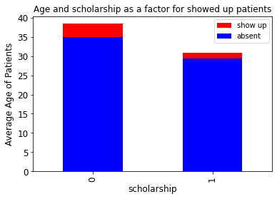

```python
# Let us visualize Age and scholarship enrollment as a factor to show up for appointment?
jack_pot('scholarship')
```

**Result:**

> 1. From the graph above, the average age of patients who showed up because they are enrolled for scholarship is Lower than the average age of patients who showed up but DID NOT received scholarship.
> 2. This means that patients above 32years and showed up for appointment are not likely to be enrolled for scholarship.
> 3. From the graph too, it is evident that average age of the patients who showed up and are enrolled for scholarship are between 0-31yrs old.

### Research Question 19: What is the average age of patients who showed up and are handicapped vs those that are not?

```python
# Average age of patients who showed up and are handicapped and Average age of patients who did not showed up and are handicapped
showed_up.groupby('handicapped').age.mean(), absent.groupby('handicapped').age.mean()
```

```
(handicapped
 0    37.506455
 1    51.724344
 2    45.095890
 3    53.400000
 4    17.000000
 Name: age, dtype: float64,
 handicapped
 0    34.068729
 1    46.874317
 2    58.351351
 3    32.666667
 4     9.000000
 Name: age, dtype: float64)
```

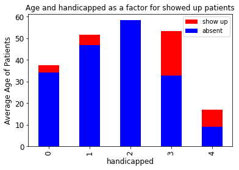

```python
# Visual representation
jack_pot('handicapped')
```

**Result:**

> 1. From the graph above, the average age of patients who showed up and are handicapped vs the average age of those that showed up and are not handicapped is **0-53yrs** *vs* **0-37years** respectively.
> 2. Those patients that were absent for appointment and are handicapped have average age of 0-58yrs.
> 3. Most stage 4 handicapped patients are more of teenagers than adults.

### Research Question 21: Does various types of health challenges prevent patients from showing up for appointment?

```python
absent.groupby(['diabetes', 'hypertension', 'alcoholism', 'handicapped']).count()['no_show']
```

```
diabetes  hypertension  alcoholism  handicapped
0         0             0           0              17603
                                    1                219
                                    2                 13
                                    3                  2
                                    4                  1
                        1           0                416
                                    1                  3
                                    2                  1
          1             0           0               2325
                                    1                 92
                                    2                 15
                                    3                  1
                        1           0                197
                                    1                  1
1         0             0           0                273
                                    1                  3
                        1           0                 12
                                    1                  1
          1             0           0               1044
                                    1                 44
                                    2                  7
                        1           0                 42
                                    1                  3
                                    2                  1
Name: no_show, dtype: int64
```

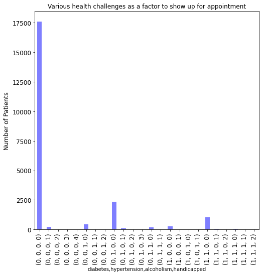

```python
Ailment_absent= absent.groupby(['diabetes', 'hypertension', 'alcoholism', 'handicapped']).count()['no_show']
Ailment_absent.plot(kind='bar', color="blue", alpha=0.5, fontsize=12, figsize=(8,8));
plt.ylabel('Number of Patients',fontsize = 12);
plt.title('Various health challenges as a factor to show up for appointment');
```

**Result:**

> 1. The graph above showed the patients who DID NOT show up for appointment because of their health disadvantages.
> 2. The analysis showed that patients that did not show up for appointment were MORE of those that HAVE NO health challenges.

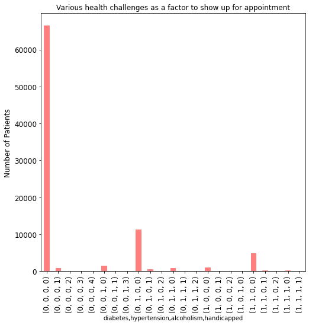

```python
Ailment_present = showed_up.groupby(['diabetes', 'hypertension', 'alcoholism', 'handicapped']).count()['no_show']
Ailment_present.plot(kind='bar', color="red", alpha=0.5, fontsize=12, figsize=(8,8));
plt.ylabel('Number of Patients',fontsize = 12);
plt.title('Various health challenges as a factor to show up for appointment');
```

**Result:**

> 1. From the graph above, it is glaring that the various health challenges analyzed DID NOT HINDER patients from showing up on the appointment day.

## Conclusions

### Limitation

> 1. Enough features that could help predict whether the patients will show up for appointment or not were not given.

### References

> 1. https://www.tutorialsandyou.com/matplotlib/how-to-show-percentage-and-value-in-matplotlib-pie-chart-12.html
> 2. https://www.stechies.com/typeerror-str-object-is-not-callable/
> 3. https://stackoverflow.com/questions/65172029/why-do-i-get-str-object-is-not-callable
> 4. https://stackoverflow.com/questions/46796574/pandas-query-error-when-column-is-an-integer.
> 5. Google search engine
> 6. ALX-Udacity Data Analysis Whatsapp group

```python
from subprocess import call
call(['python', '-m', 'nbconvert', 'Investigate_a_Dataset.ipynb'])
```